# 2020115015_inClass_2501

## 2020115015

### In Class Assignment, Dated 25/01/2024

#### Question 1

```python
import numpy as np
import matplotlib.pyplot as plt

mean = 100
std_dev = 15
size = 10
# Generate a set of random numbers from a normal distribution
data = np.random.normal(mean, std_dev, size)

# calculate mean and std dev of data
mean_data = np.mean(data)
std_dev_data = np.std(data)
print(mean_data, std_dev_data)
```

```
102.26836883942067 13.82437000300635
```

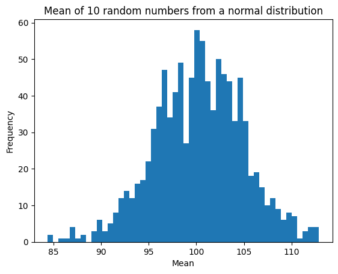

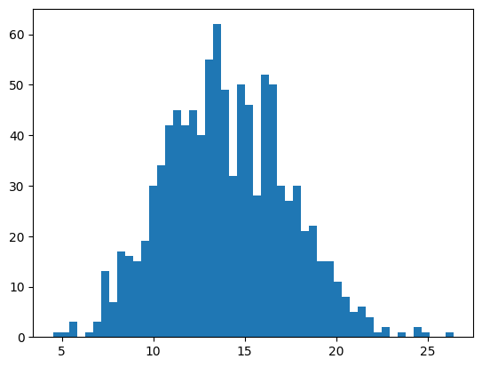

```python
means = []
std_dvs =[]
for i in range(1,1001):
    # Generate a set of random numbers from a normal distribution
    data = np.random.normal(mean, std_dev, 10)

    # calculate mean and std dev of data
    mean_data = np.mean(data)
    std_dev_data = np.std(data)
    # print(mean_data, std_dev_data)
    means.append(mean_data)
    std_dvs.append(std_dev_data)

# Plot the data
plt.hist(means, bins=50)
plt.xlabel('Mean')
plt.ylabel('Frequency')
plt.title('Mean of 10 random numbers from a normal distribution')
plt.show()

# Plot the data
plt.hist(std_dvs, bins=50)
plt.show()
```

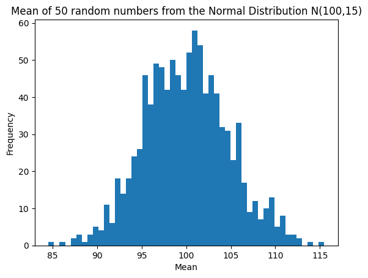

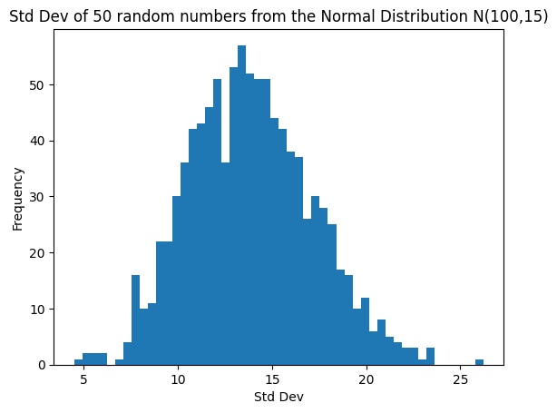

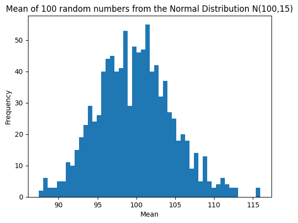

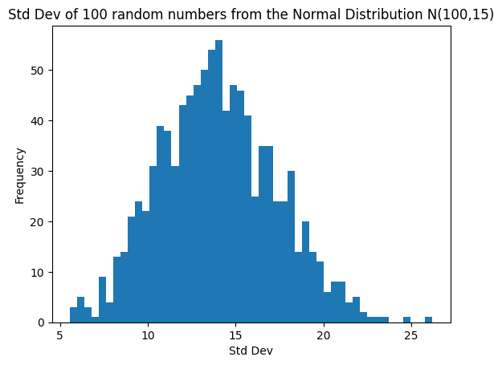

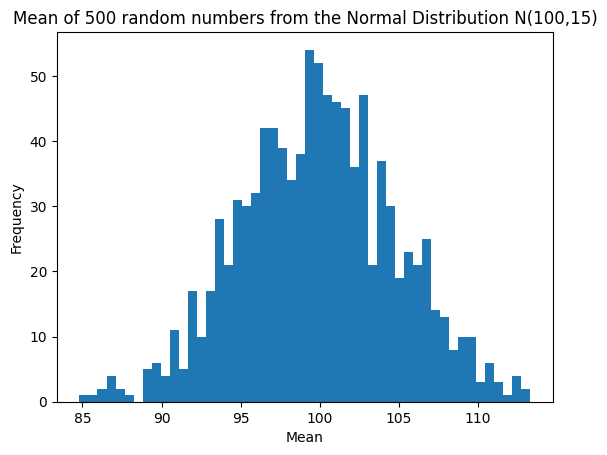

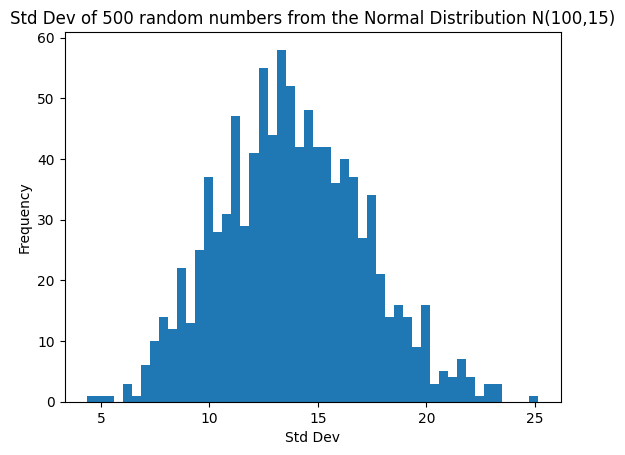

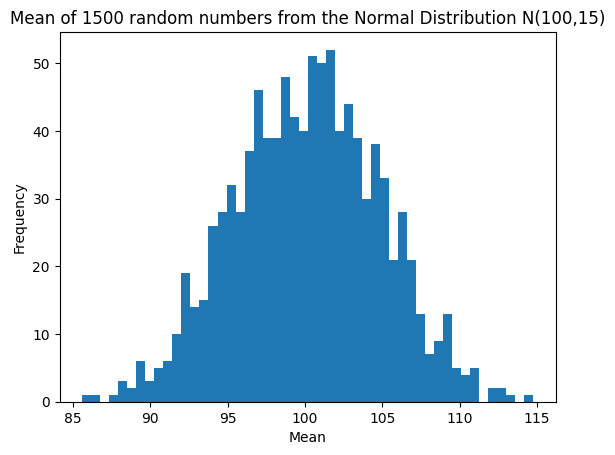

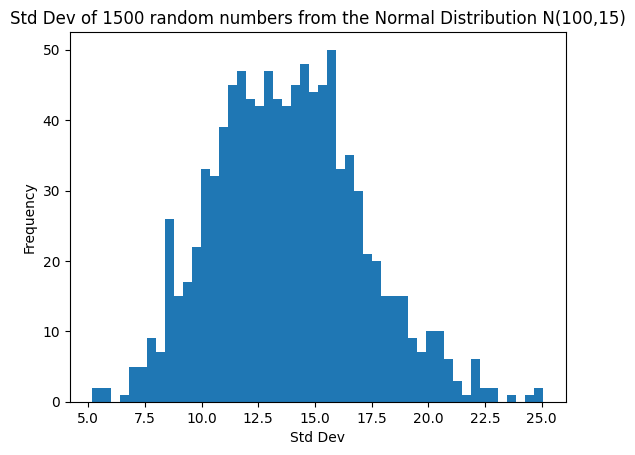

```python
for sz in [50,100,500,1500]:
    means = []
    std_dvs =[]

    for i in range(1,1001):
        # Generate a set of random numbers from a normal distribution
        data = np.random.normal(mean, std_dev, 10)

        # calculate mean and std dev of data
        mean_data = np.mean(data)
        std_dev_data = np.std(data)
        # print(mean_data, std_dev_data)
        means.append(mean_data)
        std_dvs.append(std_dev_data)

    # Plot the data
    plt.hist(means, bins=50)
    plt.xlabel('Mean')
    plt.ylabel('Frequency')
    plt.title(f'Mean of {sz} random numbers from the Normal Distribution N(100,15)')
    plt.show()

    # Plot the data
    plt.hist(std_dvs, bins=50)
    plt.xlabel('Std Dev')
    plt.ylabel('Frequency')
    plt.title(f'Std Dev of {sz} random numbers from the Normal Distribution N(100,15)')
    plt.show()
```

The above histograms are clear examples that depict the central limit theorem. We can see that drawing random samples from a distribution (N(100,15)) in this case, leads to a normal distribution of means of the datapoints obtained.

#### Question 2

```
0.28559297898678954 0.1596417053610494
```

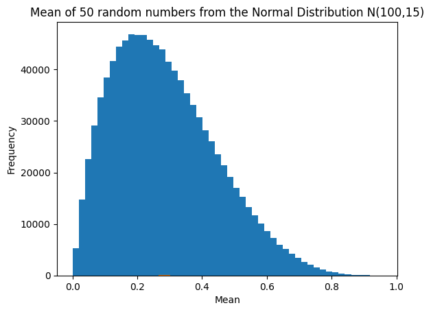

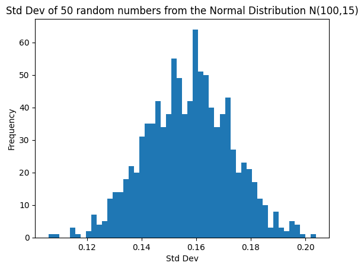

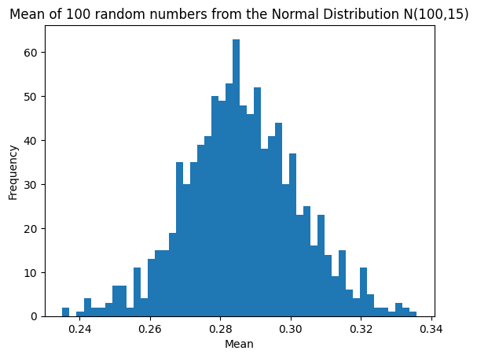

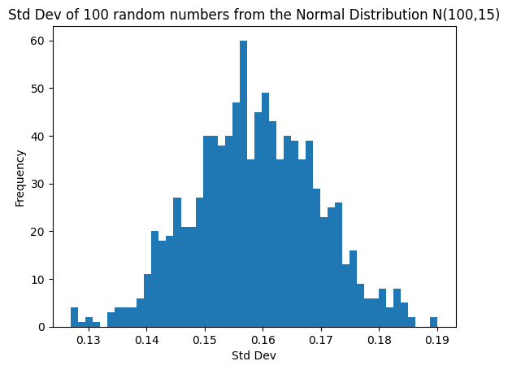

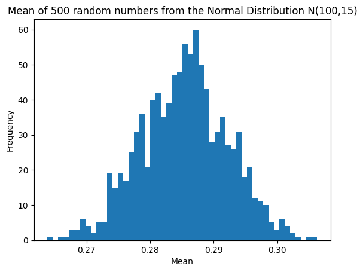

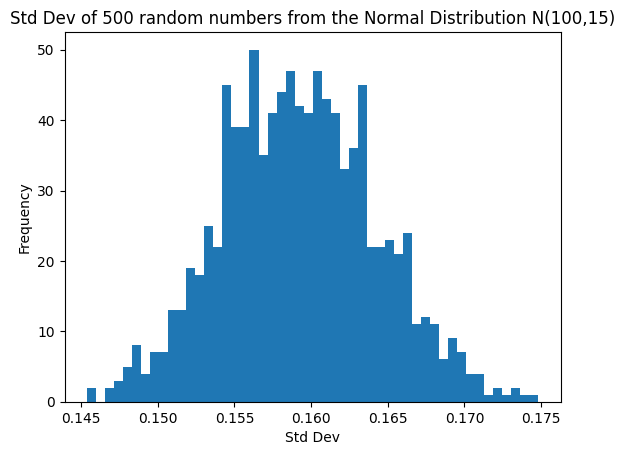

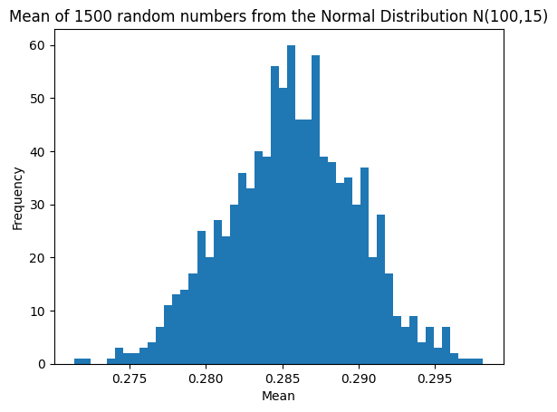

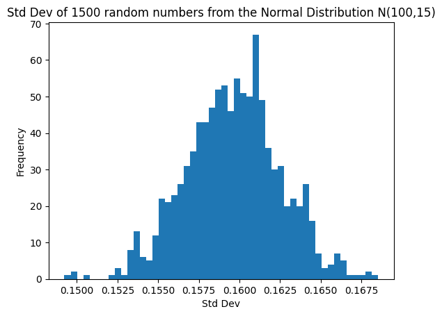

```python
beta_dis = np.random.beta(2, 5, 1000000)

print(np.mean(beta_dis), np.std(beta_dis))
# Plot the data
plt.hist(beta_dis, bins=50)
plt.xlabel('Data Points')
plt.ylabel('Frequency')
plt.title('Beta Distribution with shape parameters 2 and 5')

for sz in [50,100,500,1500]:
    means = []
    std_dvs =[]

    for i in range(1,1001):
        # Generate a set of random numbers from a beta distribution with shape parameters 2 and 5
        data = np.random.beta(2, 5, sz)

        # calculate mean and std dev of data
        mean_data = np.mean(data)
        std_dev_data = np.std(data)
        # print(mean_data, std_dev_data)
        means.append(mean_data)
        std_dvs.append(std_dev_data)

    # Plot the data
    plt.hist(means, bins=50)
    plt.xlabel('Mean')
    plt.ylabel('Frequency')
    plt.title(f'Mean of {sz} random numbers from the Normal Distribution N(100,15)')
    plt.show()

    # Plot the data
    plt.hist(std_dvs, bins=50)
    plt.xlabel('Std Dev')
    plt.ylabel('Frequency')
    plt.title(f'Std Dev of {sz} random numbers from the Normal Distribution N(100,15)')
    plt.show()
```

We again observe the central limit theorem at play. Even when we randomly sampled data points from a beta distribution, the distribution of means comes out to be a normal distribution and the mean of this distribution of means comes out to be the mean of the population we sampled from. We can see that increasing the sample size always helps as the distribution of means becomes more and more normal with increase in sample size.

Hence, when we have a large enough sample space, we can actually make use of statistical tools that work with normal distributions, which would be very useful for data analysis.

#### Question 3

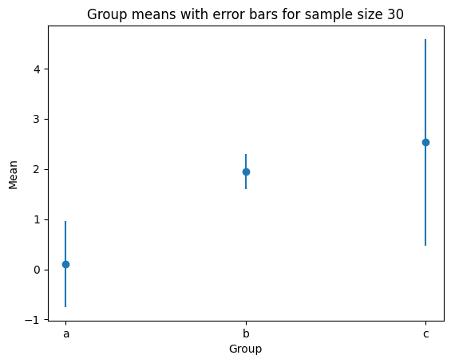

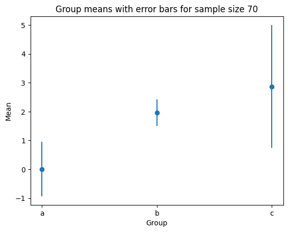

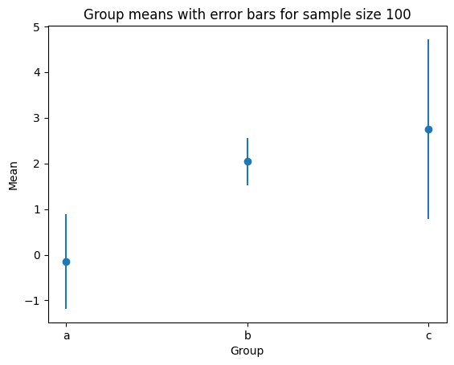

```python
for sz in [30, 70, 100]:
    a = np.random.normal(0, 1, sz)
    b = np.random.normal(2, 0.5, sz)
    c = np.random.normal(3, 2, sz)
    # calculate mean and std dev of data
    mean_a = np.mean(a)
    std_dev_a = np.std(a)
    mean_b = np.mean(b)
    std_dev_b = np.std(b)
    mean_c = np.mean(c)
    std_dev_c = np.std(c)
    # plot the mean with error bars for each group
    plt.errorbar(['a', 'b', 'c'], [mean_a, mean_b, mean_c], yerr=[std_dev_a, std_dev_b, std_dev_c], fmt='o')
    plt.xlabel('Group')
    plt.ylabel('Mean')
    plt.title(f'Group means with error bars for sample size {sz}')
    plt.show()
```

Theoritically, the confidence interval should get smaller with increase in sample size as we will become more precise in estimating the meme. However, in this case we to observe that the confidence interval did not change much. Although, in all of the sample sizes, the mean of the samples for each group revolved very close to the actual population mean.